# Regression, GLMs, and Bayesian vs Frequentist perspectives

## Setup and imports

Running this command may make PyMC3 run faster.

```python
!conda install mkl-service -y
```

```
Solving environment: done

# All requested packages already installed.
```

```python
%matplotlib inline
import numpy as np
import pandas as pd
import matplotlib.pyplot as plt
import seaborn as sns
sns.set()

import pymc3 as pm
from pymc3 import glm
import statsmodels.api as sm
import arviz
```

In this notebook, we'll be working with a dataset containing information on wind turbines.

```python
turbines = pd.read_csv('turbines.csv')
# The "year" column contains how many years since the year 2000
turbines['year'] = turbines['p_year'] - 2000
turbines = turbines.drop('p_year', axis=1)
turbines.head()
```

|  | t_state | t_built | t_cap | year |
| --- | --- | --- | --- | --- |
| 0 | AK | 6 | 390.0 | -3.0 |
| 1 | AK | 6 | 475.0 | -1.0 |
| 2 | AK | 2 | 100.0 | 0.0 |
| 3 | AK | 1 | 1500.0 | 1.0 |
| 4 | AK | 1 | 100.0 | 2.0 |

```
[]
```

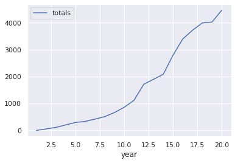

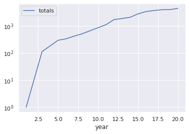

```python
# Turbines in Oklahoma (where the wind comes sweepin' down the plain...)
ok_filter = (turbines.t_state == 'OK') & (turbines.year >= 0)
ok_turbines = turbines[ok_filter].sort_values('year')
ok_turbines["totals"] = np.cumsum(ok_turbines["t_built"])
# Log-transform the counts, too
ok_turbines["log_totals"] = np.log(ok_turbines["totals"])

plt.figure()
ok_turbines.plot('year', 'totals')

plt.figure()
ok_turbines.plot('year', 'totals')
plt.semilogy()
```

Recall our problem setup:

- $X$: an $n \times d$ matrix, where each row is a data point, and each column is a feature (fixed)
- $\beta$: a $d$-dimensional vector with one coefficient for each feature (random, unknown: this is what we want)
- $y$: an $n$-dimensional vector, with a number (response variable / dependent variable) that we want to predict for each data point (random, because it depends on $\beta$ and on some error, often captured in a noise vector $\epsilon$)

The likelihood $p(y|\beta)$ usually describes the error model: in standard least squares regression, it's

$$ y|\beta \sim N(X\beta, \sigma^2 I_n) $$

Let's think about the implicit assumptions we're making by choosing this likelihood. Recall that for the normal distribution, we're very unlikely to see values more than 3$\sigma$ away from the mean. That means that we're implicitly assuming that the vast majority of $y$-values we see will be within 3$\sigma$ of the mean (i.e., the prediction $X\beta$).